# Stanford Ribonanza RNA Folding — Lightweight Linear Baseline (scikit‑learn)

This notebook implements a streamlined end-to-end workflow for the *Stanford Ribonanza RNA Folding* Kaggle competition.  
The goal is to train a fast, interpretable, and memory-efficient linear model that predicts RNA **reactivity** signals.

## Environment and Imports

This section initializes all required dependencies, configures the environment, and ensures reproducibility through fixed seeding.  
Imports cover data handling, sparse matrix construction, hashing utilities, model training modules, and evaluation helpers.

```python
import os, gc, glob, json, time, joblib, re

import pathlib as pl
from pathlib import Path
from typing import Iterator, Tuple, List

import numpy as np
import pandas as pd
from pandas.api.types import CategoricalDtype
from scipy.sparse import csr_matrix, hstack
from sklearn.linear_model import SGDRegressor
from sklearn.metrics import mean_absolute_error

import matplotlib.pyplot as plt
plt.rcParams.update({
    "figure.facecolor": "#17191a",
    "axes.facecolor": "#17191a",
    "axes.edgecolor": "white",
    "axes.labelcolor": "white",
    "xtick.color": "white",
    "ytick.color": "white",
    "text.color": "white",
    "savefig.facecolor": "#17191a",
})
plt.rcParams["axes.grid"] = False
plt.rcParams["axes.spines.top"] = False
plt.rcParams["axes.spines.right"] = False

import hashlib

# Version checks (useful for reproducibility)
import sklearn, pyarrow, numpy
import pyarrow as pa
import pyarrow.parquet as pq
print("numpy:", numpy.__version__)
print("sklearn:", sklearn.__version__)
print("pyarrow:", pyarrow.__version__)
```

```
numpy: 1.26.4
sklearn: 1.2.2
pyarrow: 19.0.1
```

Build high-dimensional sparse features from RNA sequences and experimental metadata while keeping memory usage low.

### Sequence Encoding

- CSR matrix construction for efficient storage and matrix operations

### Experimental Metadata

- One-hot encoding of experiment types (`DMS`, `2A3`)
- Inclusion of positional covariates

The resulting feature matrix is compact, scalable, and optimized for streaming mini-batch training.

```python
_ALLOWED = set("ACGU")
_TRANS = str.maketrans({
    "a":"A","c":"C","g":"G","u":"U","t":"U",
    "A":"A","C":"C","G":"G","U":"U","T":"U"
})

def normalize_seq_or_raise(seq: str) -> str:
    s = seq.translate(_TRANS)
    bad = set(s) - _ALLOWED
    if bad:
        where = [i for i,ch in enumerate(s) if ch not in _ALLOWED][:5]
        raise ValueError(f"Invalid base(s) {sorted(bad)} found at positions (first few): {where}")
    return s

_BASE2IDX = {"A":0, "C":1, "G":2, "U":3}

def make_per_base_rows(df: pd.DataFrame):
    """Expand sequence-level rows into per-base arrays (single chunk)."""

    bases, pos_fracs, exps, targets = [], [], [], []
    for _, r in df.iterrows():
        seq = normalize_seq_or_raise(str(r["sequence"]))
        y = np.asarray(r["shape_vec"], dtype=float)
        L = len(seq)
        if L != len(y):
            continue
        denom = max(1, L-1)
        exp = str(r["experiment"])
        for i, (b, val) in enumerate(zip(seq, y)):
            if not np.isfinite(val) or val == -999.0:
                continue
            bases.append(b)
            pos_fracs.append(i/denom)
            exps.append(exp)
            targets.append(float(val))
    return bases, pos_fracs, exps, targets

def to_sparse_design(bases, pos_fracs, exps) -> csr_matrix:
    n = len(bases)

    # Base OHE (n x 4) — fast dict lookup
    r, c, d = [], [], []
    for i, b in enumerate(bases):
        j = _BASE2IDX.get(b)           # must exist (normalized earlier)
        if j is None:
            raise ValueError(f"Unexpected base {b!r} after normalization")
        r.append(i); c.append(j); d.append(1.0)
    X_base = csr_matrix((d,(r,c)), shape=(n,4), dtype=np.float32)

    # Position (n x 1)
    X_pos = csr_matrix(np.asarray(pos_fracs, dtype=np.float32).reshape(-1,1))

    # Experiment OHE (n x |EXP_MAP|)
    r, c, d = [], [], []
    for i, e in enumerate(exps):
        j = EXP_MAP.get(str(e))
        if j is None:
            raise ValueError(f"Unseen Experiment label: {e!r}")
        r.append(i); c.append(j); d.append(1.0)
    X_exp = csr_matrix((d,(r,c)), shape=(n, len(EXP_MAP)), dtype=np.float32)

    X = hstack([X_base, X_pos, X_exp], format="csr")

    X.sum_duplicates()
    return X
```

## Training and Evaluation

This section defines the full training loop for the lightweight linear model.

### Validation

A held-out validation set (split by `sequence_id` to avoid leakage) is used to track performance.  
Standard error metrics are computed and printed.  
These scores guide hyperparameter tuning and provide a realistic estimate of leaderboard performance.

```python
# define array + callback ----
def on_batch(epoch, batch_idx, loss, model):
    # Only record first batch of each epoch → one point per epoch
    if batch_idx == 0:
        epoch_losses.append(loss)

def fit_sgd_on_df(
    df: pd.DataFrame,
    epochs: int = 10,
    batch_seqs: int = 8000,
    alpha=1e-5,
    eta0=5e-4,
    power_t=0.5,
    average=True,
    seed=42,
    on_batch=None,  # <-- callback(epoch, batch_idx, loss, model)
) -> SGDRegressor:
    rng = np.random.RandomState(seed)
    sgd = SGDRegressor(
        loss="squared_error",
        penalty="l2",
        alpha=alpha,
        learning_rate="invscaling",
        eta0=eta0,
        power_t=power_t,
        max_iter=1,          # driving epochs manually
        random_state=seed,
        average=average,
    )

    if len(df) == 0:
        return sgd

    for epoch in range(epochs):
        idx = rng.permutation(len(df))  # shuffle sequences per epoch

        batch_idx = 0
        for start in range(0, len(df), batch_seqs):
            chunk = df.iloc[idx[start:start+batch_seqs]]

            bases, pos_fracs, exps, y = make_per_base_rows(chunk)
            if not bases:
                continue

            X = to_sparse_design(bases, pos_fracs, exps)
            y = np.asarray(y, dtype=np.float32)

            perm = rng.permutation(X.shape[0])  # shuffle per-base rows
            X_batch = X[perm]
            y_batch = y[perm]

            # one SGD step over this batch
            sgd.partial_fit(X_batch, y_batch)

            # compute batch loss (MSE here; use MAE or RMSE if you prefer)
            if on_batch is not None:
                y_pred = sgd.predict(X_batch)
                batch_loss = float(np.mean((y_pred - y_batch) ** 2))
                on_batch(epoch, batch_idx, batch_loss, sgd)

            batch_idx += 1

    return sgd

def evaluate_on_df(model: SGDRegressor, df_val: pd.DataFrame) -> float:
    y_true, y_pred = [], []
    bases, pos_fracs, exps, targets = make_per_base_rows(df_val)
    if bases:
        X = to_sparse_design(bases, pos_fracs, exps)
        preds = model.predict(X)
        y_true.extend(targets)
        y_pred.extend(preds.tolist())
    return mean_absolute_error(y_true, y_pred) if y_true else np.nan


def split_by_seq(df: pd.DataFrame, val_frac: float = 0.2, seed: int = 7, id_col: str = "sequence_id"):
    if id_col not in df.columns:
        raise KeyError(f"Column {id_col!r} not found in DataFrame")
    uids = df[id_col].unique().tolist()
    rng = np.random.RandomState(seed)
    rng.shuffle(uids)
    # keep both splits non-empty for tiny datasets
    n_val = max(1, min(len(uids) - 1, int(round(len(uids) * val_frac))))
    val_ids = set(uids[:n_val])
    mask = df[id_col].isin(val_ids)
    train = df.loc[~mask].reset_index(drop=True)
    val   = df.loc[mask].reset_index(drop=True)
    return train, val
```

## Submission Writer (Kaggle CSV)

Utility functions for generating a Kaggle-compatible submission file.

- Produces `id, reactivity_DMS_MaP …` columns
- Efficiently handles per-experiment predictions without redundant computation
- Automatically applies experiment offsets and aligns output indices

The generated CSV can be uploaded directly using **“Save Version → Submit”** on Kaggle.

```python
_BASE2IDX = {"A": 0, "C": 1, "G": 2, "U": 3}

def to_sparse_bp_only(bases, pos_fracs):
    """
    Build sparse features (base OHE, position).
    """
    n = len(bases)
    if len(pos_fracs) != n:
        raise ValueError("bases and pos_fracs must have the same length")

    # Base OHE (n x 4)
    r, c, d = [], [], []
    for i, b in enumerate(bases):
        j = _BASE2IDX.get(b)
        if j is None:
            raise ValueError(f"Unexpected base {b!r}; expected A/C/G/U. Did you normalize earlier?")
        r.append(i); c.append(j); d.append(1.0)
    X_base = csr_matrix((d, (r, c)), shape=(n, 4), dtype=np.float32)

    # Position (n x 1)
    X_pos = csr_matrix(np.asarray(pos_fracs, dtype=np.float32).reshape(-1, 1))

    X = hstack([X_base, X_pos], format="csr")

    X.sum_duplicates()
    return X

def make_submission_from_csv_fast(
    model,
    test_csv,
    out_csv,
    exp_map=None,
    chunksize=20000,
    clip01=True,
    progress_every=None,
):
    # Resolve to globals if not provided
    exp_map = exp_map if exp_map is not None else globals()["EXP_MAP"]

    # ---- slice model weights once (layout: [base4 | pos1 | expE]) ----
    w = model.coef_.ravel()
    b = float(np.atleast_1d(model.intercept_)[0])
    off_bp = 4 + 1  # base (4) + pos (1)
    E = len(exp_map)

    # sanity
    expected_len = off_bp + E
    if w.size < expected_len:
        raise ValueError(f"Weight vector shorter than expected ({w.size} < {expected_len}). "
                         "Check N_FEATURES / model config.")

    # weights for base+pos+kmer (to pair with to_sparse_bp_only)
    w_bp = np.concatenate([w[:off_bp], w[off_bp + E: off_bp + E]])

    # scalar offsets for experiments
    try:
        w_dms = w[off_bp + exp_map["DMS"]]
        w_2a3 = w[off_bp + exp_map["2A3"]]
    except KeyError as e:
        raise KeyError(f"Missing experiment in exp_map: {e}. exp_map={exp_map}") from e

    usecols = ["id_min", "id_max", "sequence_id", "sequence"]
    reader = pd.read_csv(test_csv, usecols=usecols, chunksize=chunksize)

    with open(out_csv, "w") as f:
        f.write("id,reactivity_DMS_MaP,reactivity_2A3_MaP\n")
        processed = 0

        for df in reader:
            # unpack rows in the same order as usecols = ["id_min","id_max","sequence_id","sequence"]
            for id_min, id_max, sequence_id, seq_raw in df.itertuples(index=False, name=None):
                seq = normalize_seq_or_raise(str(seq_raw))
                L = len(seq)

                bases     = list(seq)
                pos_fracs = [i / max(1, L - 1) for i in range(L)]

                # features without experiment block
                X_bp = to_sparse_bp_only(bases, pos_fracs)

                # shared base prediction
                base_pred = X_bp.dot(w_bp) + b

                y_dms = np.clip(base_pred + w_dms, 0.0, 1.0) if clip01 else base_pred + w_dms
                y_2a3 = np.clip(base_pred + w_2a3, 0.0, 1.0) if clip01 else base_pred + w_2a3

                cur = int(id_min)
                for vd, va in zip(np.asarray(y_dms).ravel(), np.asarray(y_2a3).ravel()):
                    f.write(f"{cur},{vd:.6f},{va:.6f}\n")
                    cur += 1

                processed += 1
                if progress_every and (processed % progress_every == 0):
                    print(f"Processed {processed} sequences...", flush=True)

            gc.collect()
```

## Save / Load Model

Simple helpers for serializing and restoring the trained linear model.  
This enables:

- Fast reuse of previously trained models
- Reproducible inference runs
- Convenient warm-starts for parameter tuning experiments

```python
def save_model(model, path: Path):
    blob = {"model": model,
            "exp_map": EXP_MAP}
    path.parent.mkdir(parents=True, exist_ok=True)
    joblib.dump(blob, path)
    print("Saved:", path)

def load_model_glob(pattern="/kaggle/input/*/*.joblib") -> SGDRegressor:
    cands = glob.glob(pattern)
    assert cands, f"No model found with pattern: {pattern} (attach your dataset in Kaggle)"
    blob = joblib.load(cands[0])
    model = blob["model"]
    # restore exp map
    emap = blob.get("exp_map", None)
    if emap is not None:
        global EXP_MAP
        EXP_MAP.clear(); EXP_MAP.update(emap)
    return model
```

## Quick Parameter Tuning (Subset)

A lightweight tuning script that evaluates several configuration candidates on a small subset of the data.  
This helps identify stable settings for:

- Learning rates
- Regularization strengths
- Mini-batch sizes

Results are printed and can be transferred to the main configuration.

```python
def stratified_subset(df: pd.DataFrame, per_bucket=400, bins=5, seed=42):
    """Representative subset across Experiment x length bins."""
    rng = np.random.RandomState(seed)
    L = df["sequence"].str.len()
    qbins = pd.qcut(L, q=bins, duplicates="drop")
    df = df.assign(_len_bin=qbins)
    out = []
    for exp in df["experiment"].unique():
        for b in df["_len_bin"].dropna().unique():
            bucket = df[(df["experiment"]==exp) & (df["_len_bin"]==b)]
            if len(bucket)==0:
                continue
            take = min(per_bucket, len(bucket))
            out.append(bucket.sample(take, random_state=rng))
    sub = pd.concat(out).drop(columns=["_len_bin"]).reset_index(drop=True)
    return sub

def run_experiment(train_df, val_df, training_overrides=None):
    """Train on train_df and evaluate MAE on val_df. Returns dict with results."""
    # training params
    tparams = dict(TRAINING)
    if training_overrides:
        tparams.update(training_overrides)

    t0 = time.time()
    model = fit_sgd_on_df(
        train_df,
        epochs=tparams["epochs"],
        batch_seqs=tparams["batch_seqs"],
        alpha=tparams["alpha"],
        eta0=tparams["eta0"],
        power_t=tparams["power_t"],
        average=True,
        seed=tparams["seed"],
    )
    secs = time.time() - t0
    mae = evaluate_on_df(model, val_df)
    return {"parameters": tparams, "mae": float(mae), "seconds": round(secs,2), "model": model}
```

## Configuration

Centralized dictionary of all adjustable parameters.

### Training Hyperparameters

- Learning rate and schedule
- Regularization terms
- Batch size
- Number of epochs

### Execution Modes

Toggles for:

- Demo training
- Full training
- Submission-only inference

```python
# Fixed experiment mapping (prevents feature-dimension mismatch)
EXP_LABELS = ["DMS", "2A3"]
EXP_MAP = {exp: i for i, exp in enumerate(EXP_LABELS)}

# Optimizer config
if 'TRAINING' not in globals() or TRAINING is None:
    # Feature config (must match between training and inference)
    TRAINING = dict(
        alpha=0.001,      # L2 regularization
        eta0=0.001,       # initial learning rate
        power_t=0.5,     # decay schedule exponent
        epochs=10,        # passes over the data
        batch_seqs=1000, # sequences per mini-batch chunk
        seed=42,
    )
    print("Initialized TRAINING with defaults.")
else:
    print("TRAINING already exists — keeping your fine-tuned preset.")


# Run-mode toggles
RUN_MODE = dict(
    demo=True,           # train & validate on a small, representative subset
    parameter_tuning=False, # run hyperparameter tuning
    train_full=False,    # train on full train_df
    submit=False,        # write Kaggle submission if running on Kaggle
)


# For Kaggle, inputs are discovered under /kaggle/input.
OUTPUT_DIR = Path.cwd().parent / "outputs"
OUTPUT_DIR.mkdir(exist_ok=True, parents=True)

# Kaggle environment detection
IN_KAGGLE = os.path.exists("/kaggle/working")
```

```
Initialized TRAINING with defaults.
```

## Data Loading

```python
# -------------------------------
# File paths
# -------------------------------
TRAIN_PATH = "/kaggle/input/stanford-ribonanza-rna-folding/train_data_QUICK_START.csv"
TEST_PATH  = "/kaggle/input/stanford-ribonanza-rna-folding/test_sequences.csv"
# Read training and test CSV files into Pandas DataFrames
train = pd.read_csv(TRAIN_PATH)
test_df  = pd.read_csv(TEST_PATH)
```

```python
# =======================
# Runtime Paths & Output Config
# =======================
OUT_ROOT = Path("/kaggle/working")            # working directory for outputs
SAVE_PATH = OUT_ROOT / "fold_inputs.parquet"  # location to store processed data

# ================== CONFIG ==================
BATCH_ROWS = 2000                # tune for RAM / speed
FILL = np.float32(-999.0)        # ViennaRNA-style missing marker

# ================== COLUMN DETECTION ==================
# Required: sequence column
if "sequence" in train.columns:
    seq_col = "sequence"
else:
    raise ValueError("No 'sequence' column found in train.")

# Optional: experiment column
exp_col = None
for c in ("experiment_type", "exp", "experiment"):
    if c in train.columns:
        exp_col = c
        break

if exp_col is not None and not isinstance(train[exp_col].dtype, pd.CategoricalDtype):
    train[exp_col] = train[exp_col].astype("category")

# Optional: sequence_id column
seq_id_col = None
for c in ("sequence_id", "id", "seq_id"):
    if c in train.columns:
        seq_id_col = c
        break

# ================== REACTIVITY COLUMNS ==================
pat = re.compile(r"reactivity_(\d+)$")
keyed = []
for c in train.columns:
    m = pat.match(str(c))
    if m:
        keyed.append((int(m.group(1)), c))

react_cols = [c for _, c in sorted(keyed)]
if not react_cols:
    raise ValueError("No reactivity_* columns found in train.")

# ================== EXPERIMENT GROUPING ==================
def map_exp(x):
    if x == "DMS_MaP":
        return "DMS"
    if x == "2A3_MaP":
        return "2A3"
    return "ALL"

if exp_col is None:
    groups = [("ALL", train)]
else:
    groups = []
    cats = train[exp_col].cat.categories if hasattr(train[exp_col], "cat") else train[exp_col].unique()
    for lbl in cats:
        sub = train.loc[train[exp_col].astype(str).eq(str(lbl))]
        if len(sub):
            groups.append((map_exp(lbl), sub))

# ================== SEQUENCE → SHAPE VECTOR ==================
def row_to_shape(seq: str, row_vals: np.ndarray) -> np.ndarray:
    """
    seq: RNA sequence (string)
    row_vals: reactivity values for this row (1-based positions in columns)
    Returns: float16 vector of length len(seq), filled with FILL where missing.
    """
    L = len(seq) if isinstance(seq, str) else 0
    if L <= 0:
        return np.full(0, FILL, dtype=np.float16)

    v = np.full(L, FILL, dtype=np.float16)

    vals = row_vals.astype(np.float32, copy=False)
    vals = vals[:L]  # truncate if we have more columns than sequence length

    mask = np.isfinite(vals)
    if mask.any():
        v[np.nonzero(mask)[0]] = vals[mask].astype(np.float16, copy=False)
    return v

# ================== CLEAN START: REMOVE OLD FILE ==================
if SAVE_PATH.exists():
    SAVE_PATH.unlink()

SAVE_PATH.parent.mkdir(parents=True, exist_ok=True)

# ================== PARQUET WRITER LOOP ==================
writer = None
total_rows = 0

cols_needed = []
if seq_id_col:
    cols_needed.append(seq_id_col)
cols_needed.append(seq_col)
cols_needed.extend(react_cols)
cols_needed = [c for c in cols_needed if c is not None]

for exp_short, df_exp in groups:
    if df_exp.empty:
        continue

    df_exp = df_exp[cols_needed].copy()
    exp_rows = 0

    for start in range(0, len(df_exp), BATCH_ROWS):
        end = min(start + BATCH_ROWS, len(df_exp))
        batch = df_exp.iloc[start:end]

        # reactivity matrix
        R = batch[react_cols].to_numpy(dtype=np.float32, copy=False)

        out_rows = []
        seq_vals = batch[seq_col].astype("string").to_numpy()
        ids = batch[seq_id_col].to_numpy() if seq_id_col else None

        for i, seq in enumerate(seq_vals):
            seq_str = "" if seq is pd.NA else str(seq)
            vec = row_to_shape(seq_str, R[i])

            row = {
                "experiment": exp_short,
                "sequence": seq_str,
                "shape_vec": vec,
            }
            if ids is not None:
                row["sequence_id"] = ids[i]
            out_rows.append(row)

        df_out = pd.DataFrame(out_rows)

        # nice column order
        col_order = []
        if "sequence_id" in df_out.columns:
            col_order.append("sequence_id")
        col_order += ["sequence", "experiment", "shape_vec"]
        df_out = df_out[col_order]

        # convert ndarray → list for parquet
        df2 = df_out.copy()
        df2["shape_vec"] = df2["shape_vec"].apply(lambda a: a.tolist())

        table = pa.Table.from_pandas(df2, preserve_index=False)

        # lazily create writer when we see first chunk
        if writer is None:
            writer = pq.ParquetWriter(
                SAVE_PATH,
                table.schema,
                compression="zstd"
            )

        writer.write_table(table)
        batch_n = len(df_out)
        total_rows += batch_n
        exp_rows += batch_n

    # one summary line per experiment
    print(f"Experiment {exp_short}: wrote {exp_rows} rows")

if writer is not None:
    writer.close()

print(f"\nSaved fold_inputs to: {SAVE_PATH} with {total_rows} total rows")
```

```
Experiment 2A3: wrote 167808 rows
Experiment DMS: wrote 167808 rows

Saved fold_inputs to: /kaggle/working/fold_inputs.parquet with 335616 total rows
```

```python
P = pl.Path("/kaggle/working/fold_inputs.parquet")
train_df = pd.read_parquet(P, columns=["sequence_id","sequence","experiment","shape_vec"])
print(train_df.shape)
train_df.head(3)
```

```
(335616, 4)
```

|  | sequence_id | sequence | experiment | shape_vec |
| --- | --- | --- | --- | --- |
| 0 | 0000d87cab97 | GGGAACGACUCGAGUAGAGUCGAAAAAGAUCGCCACGCACUUACGA... | 2A3 | [-999.0, -999.0, -999.0, -999.0, -999.0, -999.... |
| 1 | 0001ca9d21b0 | GGGAACGACUCGAGUAGAGUCGAAAAGGUGGCCGGCAGAAUCGCGA... | 2A3 | [-999.0, -999.0, -999.0, -999.0, -999.0, -999.... |
| 2 | 00021f968267 | GGGAACGACUCGAGUAGAGUCGAAAACAUUGUUAAUGCCUAUAUUA... | 2A3 | [-999.0, -999.0, -999.0, -999.0, -999.0, -999.... |

## Demo: Train on a Small Subset and Validate

A fast demonstration that trains the lightweight model on a small subset of the data.  
Useful for:

- Verifying correctness
- Checking performance trends
- Iterating quickly on feature or model changes

Outputs include validation metrics and basic diagnostics.

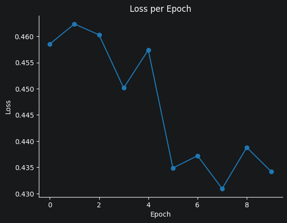

```
Validation MAE on subset: 0.36542
```

```python
if RUN_MODE["demo"] and (train_df is not None):
    demo = stratified_subset(train_df, per_bucket=400, bins=5, seed=42)
    tr, va = split_by_seq(demo, val_frac=0.2, seed=7)

    epoch_losses = []

    model = fit_sgd_on_df(
        tr,
        epochs=TRAINING["epochs"],
        batch_seqs=TRAINING["batch_seqs"],
        alpha=TRAINING["alpha"],
        eta0=TRAINING["eta0"],
        power_t=TRAINING["power_t"],
        average=True,
        seed=TRAINING["seed"],
        on_batch=on_batch,
    )
    plt.ioff()
    plt.plot(epoch_losses, marker="o")
    plt.xlabel("Epoch")
    plt.ylabel("Loss")
    plt.title("Loss per Epoch")
    plt.savefig("/kaggle/working/Simple_linear_model_epoch_loss.png", dpi=150, bbox_inches="tight")
    plt.show()
    mae = evaluate_on_df(model, va)
    print(f"Validation MAE on subset: {mae:.5f}")
else:
    print("Demo is skipped (RUN_MODE['demo']=False)")
```

## Appendix: Notes on Sparsity and Hashing

Additional commentary on the design choices behind sparse modeling.

Key insights:

- CSR matrices dramatically reduce memory footprint
- Linear models converge quickly on sparse inputs
- Averaged updates improve stability and reduce variance

## Run the Parameter Tuning (Subset)

Executes the quick tuning loop, prints the best-performing parameter set, and suggests updates for the main configuration.

```python
# ---- Run the tuning if train_df is available ----
if RUN_MODE['parameter_tuning'] and 'train_df' in globals() and train_df is not None:
    # Build a representative subset and split
    subset = stratified_subset(train_df, per_bucket=400, bins=5, seed=42)
    tr, va = split_by_seq(subset, val_frac=0.2, seed=7)

    # Define a small grid
    grid = [
    {"alpha": a, "eta0": e, "epochs": epo, "batch_seqs": b, "power_t": p}
    for a in [0, 1e-7, 1e-6, 1e-5, 1e-4, 1e-3]
    for e in [5e-4, 1e-3, 2e-3, 5e-3]
    for epo in [1,2,3]
    for b in [1000]
    for p in [0.0, 0.25, 0.5]
]

    results = []
    for params in grid:
        res = run_experiment(tr, va, training_overrides= params)
        entry = dict(params)
        entry.update({"mae": res["mae"], "seconds": res["seconds"]})

        results.append(entry)

    res_df = pd.DataFrame(results).sort_values("mae").reset_index(drop=True)
    display(res_df.head(10))

    # Persist results and pick winner
    res_csv = OUTPUT_DIR / "tuning_results.csv"
    res_df.to_csv(res_csv, index=False)
    print("Saved tuning table:", res_csv)

    best = res_df.iloc[0].to_dict()
    print("\nChosen config:", {p: best[p] for p in ["alpha","eta0","epochs","batch_seqs","power_t"]})

    # Update globals to the winner (so following cells use them)
    for k in ["alpha","eta0","epochs","batch_seqs","power_t"]:
        if k in best:
            TRAINING[k] = type(TRAINING[k])(best[k])

else:
    print("Tuning skipped.")
```

```
Tuning skipped.
```

## Train on Full In-Memory DataFrame

Runs the full training pipeline using the entire dataset.  
Trained weights are saved for later inference or submission generation.

```python
# Train on full DF and SAVE the model
if RUN_MODE["train_full"] and (train_df is not None):

    epoch_losses = []

    model = fit_sgd_on_df(
        train_df,
        epochs=TRAINING["epochs"],
        batch_seqs=TRAINING["batch_seqs"],
        alpha=TRAINING["alpha"],
        eta0=TRAINING["eta0"],
        power_t=TRAINING["power_t"],
        average=True,
        seed=TRAINING["seed"],
        on_batch=on_batch,
    )
    plt.ioff()
    plt.plot(epoch_losses, marker="o")
    plt.xlabel("Epoch")
    plt.ylabel("Loss")
    plt.title("Loss per Epoch")
    plt.show()

    # save to outputs/
    save_path = OUTPUT_DIR / f"final_sgd.joblib"
    save_model(model, save_path)  # uses the helper from the notebook
```

## Submission (Kaggle)

Final step:  
Load the trained model, apply it to the test sequences, generate the submission DataFrame, and write the Kaggle CSV.

Instructions for exporting and submitting are included for convenience.

```python
if RUN_MODE["submit"] and IN_KAGGLE:
    # Load model (uploaded as a Kaggle Dataset)
    model = load_model_glob(pattern="/kaggle/input/final_sgd/scikitlearn/default/1/final_sgd.joblib")
    TEST_CSV = "/kaggle/input/stanford-ribonanza-rna-folding/test_sequences.csv"
    OUT = "/kaggle/working/submission.csv"
    make_submission_from_csv_fast(model, TEST_CSV, OUT, exp_map=EXP_MAP, chunksize=20000)
    print("Wrote:", OUT)
else:
    if IN_KAGGLE:
        print("Submission skipped. Set RUN_MODE['submit']=True to generate submission.csv.")
    else:
        print("Not running on Kaggle. Submission block is inactive.")
```

[output not shown]